# Chapter 2 Homework

## 2.44

1. Describe the distribution of total personal income.

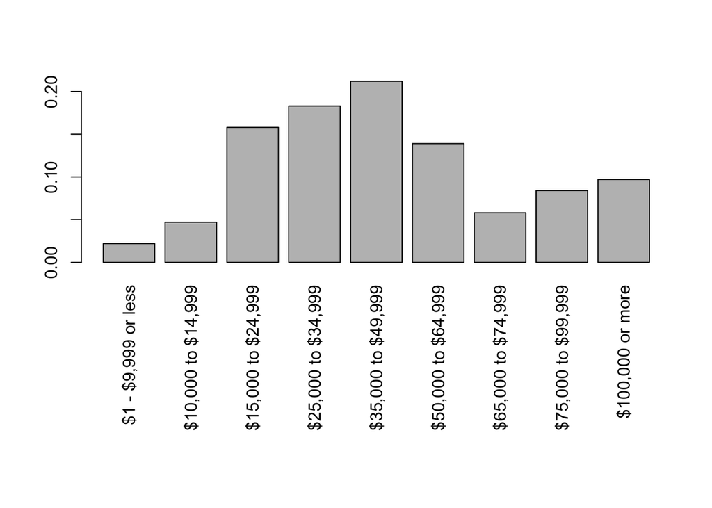

```r
income <- c('$1 - $9,999 or less',
            '$10,000 to $14,999',
            '$15,000 to $24,999',
            '$25,000 to $34,999',
            '$35,000 to $49,999',
            '$50,000 to $64,999',
            '$65,000 to $74,999',
            '$75,000 to $99,999',
            '$100,000 or more')
percenttotal = c(.022,
                 .047,
                 .158,
                 .183,
                 .212,
                 .139,
                 .058,
                 .084,
                 .097)

incomedf <- data.frame(income, percenttotal)
par(mar = c(12, 4,4,2))
barplot(incomedf$percenttotal, names.arg = incomedf$income, las =3)
```

2. What is the probability that a randomly chosen US resident makes less than $50,000 per year?

```r
sum(incomedf$percenttotal[0:5])
```

```
## [1] 0.622
```

3. What is the probability that a randomly chosen US resident makes less than $50,000 per year and is female? Note any assumptions you make.

```r
The sample was 41% female, therefore multiplying the answer from (b) by 0.41 shoudl give us the answer.
```

```r
sum(incomedf$percenttotal[0:5]) * 0.41
```

```
## [1] 0.25502
```

4. The same data source indicates that 71.8% of females make less than $50,000 per year. Use this value to determine whether or not the assumption you made in part (c) is valid.

```r
I would not consider the assumption I made in part (c) to be valid because the distribution of income between gender varies with income range.  In part (b) we calculated that 62.2% of the sample population is making less than 50k. Which means there this many people are earning below 50k from the sample:
```

```r
96420486 * .62
```

```
## [1] 59780701
```

```r
The number of females in the sample:
```

```r
96420486 * .41
```

```
## [1] 39532399
```

```r
Multiplying the number of females in the sample by 0.718 and then dividing by the number of people earning less than 50k returns 0.47 which differs from the 0.41 value given to us in part (c).
```

```r
(39532399 * .718) / 59780701
```

```
## [1] 0.4748065
```